# Market Segmentation for a B2B Company

**INSEAD Data Analytics Group Project**

## Some Code/Analysis from the course material/tools

```r
ProjectDatafactor_scaled = apply(ProjectDataFactor, 2, function(r) {
    if (sd(r) != 0)
        res = (r - mean(r))/sd(r) else res = 0 * r
    res
})
```

[output not shown]

## Our Approach

1. Confirm the data in metric
2. Decide whether to scale or standardize the data
3. Decide which variables to use for clustering
4. Define similarity or dissimilarity measures between observations
5. Visualize Individual Attributes and Pair-wise Distances between the Observations
6. Select the clustering method to use and decide how many clusters to have
7. Profile and interpret the clusters
8. Assess the robustness of our clusters

Let's follow these steps.

#### 2. Decide whether to scale or standardize the data

```r
ProjectData_scaled <- apply(ProjectData, 2, function(r) {
    if (sd(r) != 0)
        res = (r - mean(r))/sd(r) else res = 0 * r
    res
})

# ProjectData_scaled <- ProjectData

# print(ProjectData_scaled)
```

While this is typically a necessary step, one has to always do it with care: some times you may want your analytics findings to be driven mainly by a few attributes that take large values; other times having attributes with different scales may imply something about those attributes. In many such cases one may choose to skip step 2 for some of the raw attributes.

#### Step 4. Define similarity or dissimilarity measures between observations

In our case we explore two distance metrics: the commonly used **Euclidean distance** as well as a simple one we define manually.

Pairwise Distances between the first 5 observations using The Euclidean Distance Metric

| 1 | 2 | 3 | 4 | 5 |
| --- | --- | --- | --- | --- |
| 0.0 |  |  |  |  |
| 3.4 | 0.0 |  |  |  |
| 3.3 | 2.2 | 0.0 |  |  |
| 3.8 | 1.9 | 3.5 | 0.0 |  |
| 1.9 | 3.6 | 3.2 | 4.1 | 0.0 |

Notice for example that if we use, say, the Manhattan distance metric, these distances change as follows:

Pairwise Distances between the first 5 observations using The Manhattan Distance Metric

| 1 | 2 | 3 | 4 | 5 |
| --- | --- | --- | --- | --- |
| 0.0 |  |  |  |  |
| 4.9 | 0.0 |  |  |  |
| 6.2 | 4.9 | 0.0 |  |  |
| 7.4 | 4.2 | 6.5 | 0.0 |  |
| 4.4 | 8.1 | 6.7 | 8.8 | 0.0 |

Let's now define our own distance metric, as an example. Let's say that the management team of the company believes that two customers are similar if they do not differ in their ratings of the attitudinal questions by more than 2 points. We can manually assign a distance of 1 for every question for which two customers gave an answer that differs by more than 2 points, and 0 otherwise. It is easy to write this distance function in R:

```r
My_Distance_function <- function(x, y) {
    sum(abs(x - y) > 2)
}
```

Here is how the pairwise distances between the respondents now look like.

Pairwise Distances between the first 5 observations using a simple manually defined Distance Metric

| 1 | 2 | 3 | 4 | 5 |
| --- | --- | --- | --- | --- |
| 0.0 |  |  |  |  |
| 1.0 | 0.0 |  |  |  |
| 1.0 | 0.0 | 0.0 |  |  |
| 2.0 | 0.0 | 2.0 | 0.0 |  |
| 0.0 | 1.0 | 1.0 | 1.0 | 0.0 |

In general a lot of creative thinking and exploration should be spent in this step, and as always one may need to come back to this step even after finishing the complete segmentation process - multiple times.

#### Step 5. Visualize Individual Attributes and Pair-wise Distances between the Observations

or the histogram of all pairwise distances for the euclidean distance:

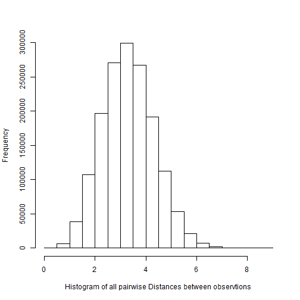

> Visualization is very important for data analytics, as it can provide a first understanding of the data.

#### Step 6. Select the clustering method to use and decide how many clusters to have

In this note we will use two widely used methods: the **Kmeans Clustering Method**, and the **Hierarchical Clustering Method**. Like all clustering methods, these two also require that we have decided how to measure the distance/similarity between our observations. Explaining how these methods work is beyond our scope. The only difference to highlight is that Kmeans requires the user to define how many segments to create, while Hierarchical Clustering does not.

Let's fist use the **Hierarchial Clustering** method, as we do not know for now how many segments there are in our data. Hierarchical clustering is a method that also helps us visualise how the data may be clustering together. It generates a plot called the **Dendrogram** which is often helpful for visualization - but should be used with care. For example, in this case the dendrogram, using the euclidean distance metric from the earlier steps and the ward hierarchical clustering option (see below as well as help(hclust) in R for more information), is as follows:

[figure not shown]

Note that we can draw as many clusters are we choose (e.g. in this case we chose 4 clusters) around the branches of the Dendrogram.

#### Step 7. Profile and interpret the clusters

We can also “visualize” the segments using **snake plots** for each cluster. For example, we can plot the means of the profiling variables for each of our clusters to better visualize differences between segments. For better visualization we plot the standardized profiling variables.

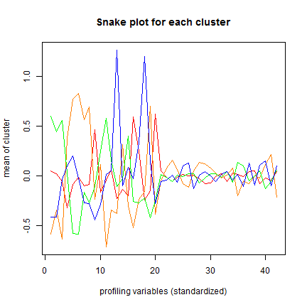

We can also compare the averages of the profiling variables of each segment relative to the average of the variables across the whole population. This can also help us better understand whether there are indeed clusters in our data (e.g. if all segments are much like the overall population, there may be no segments). For example, we can measure the ratios of the average for each cluster to the average of the population (e.g. avg(cluster)/avg(population)) and explore a matrix as the following one:

|  | Segment 1 | Segment 2 | Segment 3 | Segment 4 |
| --- | --- | --- | --- | --- |
| MAXDIFF: Material selection support | 1.034 | 0.5827 | 1.423 | 0.7036 |
| MAXDIFF: Processing support | 1.017 | 0.7378 | 1.337 | 0.685 |
| MAXDIFF: Application development support | 0.9523 | 0.4822 | 1.452 | 0.9711 |
| MAXDIFF: Total system cost reduction | 0.8436 | 1.181 | 1.014 | 1.048 |
| MAXDIFF: Efficient and reliable ordering process | 0.9195 | 1.736 | 0.4464 | 1.189 |
| MAXDIFF: Delivery &amp; inventory management | 0.9875 | 1.656 | 0.5365 | 0.9808 |
| MAXDIFF: Low material price | 0.9475 | 1.285 | 0.9171 | 0.8624 |
| MAXDIFF: Formula based or fixed material price | 0.9239 | 1.589 | 0.7704 | 0.7586 |
| MAXDIFF: Material coloring solutions | 1.628 | 0.6737 | 0.8551 | 0.397 |
| MAXDIFF: Account manager relationship | 0.8674 | 1.091 | 1.197 | 0.7703 |
| MAXDIFF: Collaboration during your innovation process | 0.9656 | 0.4697 | 1.427 | 1.01 |
| MAXDIFF: Collaboration for growth | 1.082 | 0.5677 | 1.199 | 1.061 |
| MAXDIFF: Support towards your sustainability goals | 0.7106 | 0.5233 | 0.8665 | 2.58 |
| MAXDIFF: Material quality | 0.9694 | 1.069 | 0.9941 | 0.9772 |
| MAXDIFF: Supplier expertise of your industry | 0.8289 | 0.7438 | 1.342 | 1.075 |
| MAXDIFF: Global service and operations | 1.772 | 0.3232 | 0.6647 | 0.9651 |
| MAXDIFF: Local service and operations | 1.242 | 0.7691 | 0.738 | 1.324 |
| MAXDIFF: Business services | 0.5803 | 0.7318 | 0.6242 | 3.034 |
| MAXDIFF: Credit limit. financing and payment terms | 0.7798 | 2.016 | 0.3824 | 1.209 |
| MAXDIFF: Broad material portfolio | 1.954 | 0.399 | 0.6114 | 0.5653 |
| Willing to Changing suppliers | 1.021 | 0.9795 | 1.005 | 0.976 |
| Willing to Give more business | 0.9962 | 1.017 | 0.9965 | 0.9897 |
| Willing to Recommend to others | 0.986 | 1.038 | 0.9859 | 1.002 |
| Willing to Specify as supplier of choice | 0.9965 | 1.013 | 1.001 | 0.9871 |
| Willing to Pay for consulting services | 1.007 | 0.9663 | 0.997 | 1.04 |
| Willing to Pay price premium | 0.9993 | 0.9527 | 1.009 | 1.053 |
| Changed material suppliers in past | 1.002 | 1.023 | 1.01 | 0.9411 |
| Given more business in past | 0.9872 | 1.062 | 0.9674 | 1.002 |
| Recommended to others in past | 0.9492 | 1.078 | 0.9855 | 1.026 |
| Specify as supplier of choice in past | 0.96 | 1.043 | 1.013 | 0.9982 |
| Paid for consulting services in past | 0.9758 | 1.077 | 1.051 | 0.8399 |
| Paid premium in past | 1.05 | 0.9579 | 0.959 | 1.032 |
| Will - Order large quantity for lower price | 0.9825 | 1.001 | 1.012 | 1.013 |
| Will accept - No sales rep for lower price | 1.012 | 1.03 | 0.9733 | 0.982 |
| Will accept - Cancellation fees for lower price | 1.004 | 0.9159 | 1.055 | 1.006 |
| Will accept - Longer lead times for lower price | 0.9965 | 0.9776 | 1.045 | 0.9525 |
| Will accept - Broader materials specs for lower price | 1.018 | 0.9663 | 0.9781 | 1.052 |
| Will - Use own transportation for lower price | 1.019 | 0.9997 | 0.9988 | 0.9615 |
| Will - Allocate more spending to supplier for lower price | 0.98 | 0.9951 | 1.012 | 1.027 |
| Will - Give up support for lower price | 0.9881 | 1.053 | 0.9392 | 1.067 |
| Price Importance | 0.986 | 1.066 | 0.9819 | 0.9692 |
| Quality and service importance | 1.015 | 0.9273 | 1.02 | 1.034 |

#### Step 8. Assess the robustness of our clusters

We will skip this step for this exercise. However in practice this is a very important step.